# BIOM/SYSC 5405: Pattern Classification and Experiment Design

Assignment 1

Romeo Penheiro

Department of Cognitive Science, Carleton University

11/09/2021

```r
# Install xfun so that I can use xfun::pkg_load2
if (!requireNamespace('xfun')) install.packages('xfun')
xf <- loadNamespace('xfun')

cran_packages = c(
                  "dplyr",
                  "ggplot2",
                  "knitr",
                  "readxl",
                  "tibble",
                  "skimr",
                  "kableExtra",
                  "gridExtra",
                  "here",
                  "utils",
                  "tidyr",
                  "stats",
                  "ggpubr",
                  "MASS"
                  )
if (length(cran_packages) != 0) xf$pkg_load2(cran_packages)

import::from(magrittr, '%>%')
gg <- import::from(ggplot2, .all=TRUE, .into={new.env()})
dp <- import::from(dplyr, .all=TRUE, .into={new.env()})
```

load the files

```r
pci_raw <- readxl::read_xls(path = here::here("data", "assigData1.xls"),
                            sheet = "PCI")
```

```
## * `` -> ...1
```

```r
psipred_raw <- readxl::read_xls(path = here::here("data", "assigData1.xls"),
                            sheet = "PSIPRED")
```

```
## * `` -> ...1
```

```r
feature_raw_data <- utils::read.table(file = here::here("data", "assigData2.tsv"), sep = '\t', header = TRUE)
feature_raw_data
```

| W_apl | W_orng | W_grp | D_apl | D_orng | D_grp |
| --- | --- | --- | --- | --- | --- |
| 8.752749 | 6.320049 | 5.823010 | 1027.5515 | 1120.361 | 887.1437 |
| 9.582232 | 11.608371 | 7.629106 | 1032.1657 | 1120.328 | 865.5492 |
| 11.319934 | 9.005328 | 4.462647 | 921.7944 | 1101.821 | 787.5704 |
| 10.762629 | 11.430149 | 5.825027 | 1013.8796 | 1142.611 | 723.6004 |
| 14.026474 | 18.170749 | 5.415419 | 1089.0688 | 1099.741 | 816.9853 |
| 9.443416 | 12.084715 | 4.547281 | 1006.1598 | 1109.431 | 825.9677 |
| 10.731744 | 15.773819 | 4.995380 | 989.6158 | 1102.384 | 658.3416 |
| 11.044276 | 9.223214 | 5.803120 | 976.4181 | 1097.368 | 949.3001 |
| 9.488788 | 15.188932 | 8.027023 | 947.2622 | 1118.196 | 876.4103 |
| 12.187106 | 7.815964 | 6.152356 | 995.2333 | 1086.468 | 693.4036 |

[output cut: 90 more lines]

# Explore the data

```r
tibble::glimpse(pci_raw)
```

```
## Rows: 125
## Columns: 5
## $ ...1   <chr> "1NEI_A", "1NNG_A", "1NXH_A", "1OJH_A", "1OYI_A", "1PGY_A", "1P…
## $ Length <dbl> 60, 141, 124, 52, 62, 47, 32, 60, 60, 38, 62, 102, 194, 53, 90,…
## $ CC     <dbl> 0.764, 0.899, 0.568, 0.786, 0.665, 0.781, 0.200, 0.879, 0.907, …
## $ Q3     <dbl> 85.00, 92.91, 76.61, 90.38, 82.26, 85.11, 46.88, 90.00, 93.33, …
## $ BAD    <dbl> 5.000, 0.000, 0.000, 0.000, 3.226, 0.000, 0.000, 0.000, 0.000, …
```

```r
tibble::glimpse(psipred_raw)
```

```
## Rows: 125
## Columns: 5
## $ ...1   <chr> "1NEI_A", "1NNG_A", "1NXH_A", "1OJH_A", "1OYI_A", "1PGY_A", "1P…
## $ Length <dbl> 60, 141, 124, 52, 62, 47, 32, 60, 60, 38, 62, 102, 194, 53, 90,…
## $ CC_AVG <dbl> 0.796, 0.920, 0.568, 0.872, 0.632, 0.797, 0.183, 0.847, 0.899, …
## $ Q3     <dbl> 86.67, 94.33, 77.42, 94.23, 80.65, 87.23, 46.88, 88.33, 93.33, …
## $ BAD    <dbl> 5.000, 0.000, 0.000, 0.000, 3.226, 0.000, 0.000, 0.000, 0.000, …
```

# Question 1: Classifier scores

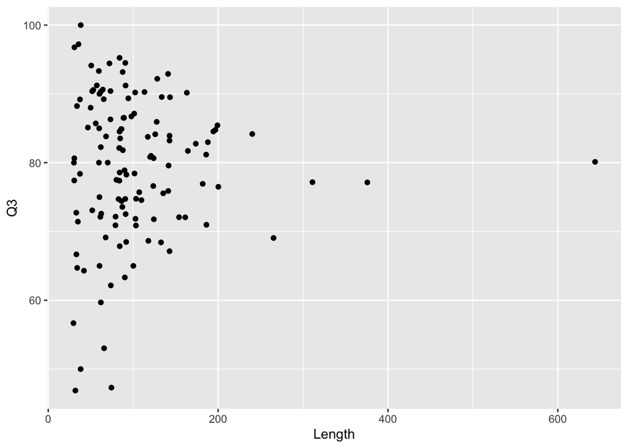

```r
q3_length_pci <- gg$ggplot(data = pci_raw, mapping = gg$aes(x = Length, y = Q3)) +
  gg$geom_jitter()
q3_length_pci
```

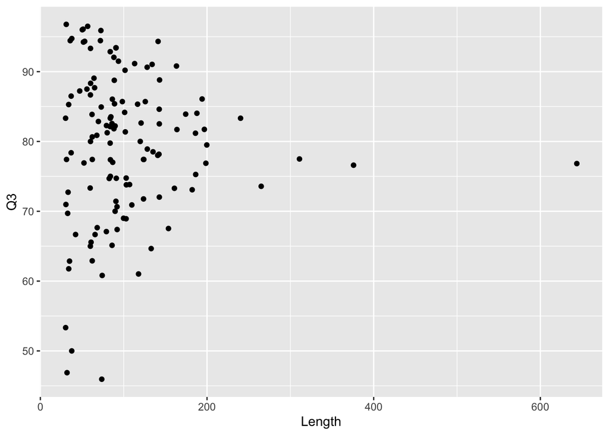

```r
q3_length_psipred <- gg$ggplot(data = psipred_raw, mapping = gg$aes(x = Length, y = Q3)) +
  gg$geom_jitter()
q3_length_psipred
```

Based on these plots, there does not seem to be a correlation between Q3 accuracy with protein length for both the methods.

Spearmen co-relation between the two variables

```r
cor.test(pci_raw$Length, pci_raw$Q3,
         method = "spearman",
         exact = FALSE)
```

```
##
##  Spearman's rank correlation rho
##
## data:  pci_raw$Length and pci_raw$Q3
## S = 330008, p-value = 0.8782
## alternative hypothesis: true rho is not equal to 0
## sample estimates:
##         rho
## -0.01384834
```

```r
cor.test(psipred_raw$Length, psipred_raw$Q3,
         method = "spearman",
         exact = FALSE)
```

```
##
##  Spearman's rank correlation rho
##
## data:  psipred_raw$Length and psipred_raw$Q3
## S = 334217, p-value = 0.7669
## alternative hypothesis: true rho is not equal to 0
## sample estimates:
##         rho
## -0.02678139
```

Why did I use Spearman’s correlation? https://ademos.people.uic.edu/Chapter22.html http://www.statstutor.ac.uk/resources/uploaded/spearmans.pdf https://www.quora.com/What-is-the-difference-between-dependence-and-correlation

mean, median, and standard deviation of the Matthews’ correlation coefficien

```r
# Using the `skimr` function
# Create a template function for descriptives
my_skim <- skimr::skim_with(base = skimr::sfl(n = length,
                                              missing =skimr::n_missing),
                            numeric = skimr::sfl(mean,
                                                 sd,
                                                 iqr = IQR, # stats::IQR
                                                 min,
                                                 p25 = ~ quantile(., 1/4),
                                                 median,
                                                 p75 = ~ quantile(., 3/4),
                                                 max
                                                 ), append = FALSE
) #sfl stands for "skimr function list"
```

```r
my_skim(pci_raw$CC)
```

Data summary

| Name | pci_raw$CC |
| --- | --- |
| Number of rows | 125 |
| Number of columns | 1 |
| _______________________ |  |
| Column type frequency: |  |
| numeric | 1 |
| ________________________ |  |
| Group variables | None |

**Variable type: numeric**

| skim_variable | n | missing | mean | sd | iqr | min | p25 | median | p75 | max |
| --- | --- | --- | --- | --- | --- | --- | --- | --- | --- | --- |
| data | 125 | 0 | 0.66 | 0.18 | 0.24 | 0.14 | 0.54 | 0.67 | 0.79 | 0.96 |

```r
my_skim(psipred_raw$CC_AVG)
```

Data summary

| Name | psipred_raw$CC_AVG |
| --- | --- |
| Number of rows | 125 |
| Number of columns | 1 |
| _______________________ |  |
| Column type frequency: |  |
| numeric | 1 |
| ________________________ |  |
| Group variables | None |

**Variable type: numeric**

| skim_variable | n | missing | mean | sd | iqr | min | p25 | median | p75 | max |
| --- | --- | --- | --- | --- | --- | --- | --- | --- | --- | --- |
| data | 125 | 0 | 0.66 | 0.18 | 0.22 | 0.14 | 0.56 | 0.67 | 0.78 | 0.94 |

# Question 2: Feature data

# (a) Estimation of the class-conditional distribution parameters of each feature and for each class

```r
my_skim(feature_raw_data)
```

Data summary

| Name | feature_raw_data |
| --- | --- |
| Number of rows | 100 |
| Number of columns | 6 |
| _______________________ |  |
| Column type frequency: |  |
| numeric | 6 |
| ________________________ |  |
| Group variables | None |

**Variable type: numeric**

| skim_variable | n | missing | mean | sd | iqr | min | p25 | median | p75 | max |
| --- | --- | --- | --- | --- | --- | --- | --- | --- | --- | --- |
| W_apl | 100 | 0 | 11.00 | 1.18 | 1.72 | 7.09 | 10.14 | 11.01 | 11.87 | 14.03 |
| W_orng | 100 | 0 | 11.94 | 2.61 | 3.64 | 5.25 | 10.16 | 11.79 | 13.80 | 18.17 |
| W_grp | 100 | 0 | 8.73 | 4.98 | 9.57 | 2.07 | 4.57 | 5.82 | 14.14 | 17.35 |
| D_apl | 100 | 0 | 1006.71 | 40.27 | 50.08 | 877.88 | 981.32 | 1011.18 | 1031.39 | 1091.80 |
| D_orng | 100 | 0 | 1114.83 | 19.58 | 25.47 | 1074.38 | 1101.53 | 1115.48 | 1127.00 | 1162.49 |
| D_grp | 100 | 0 | 832.55 | 91.41 | 105.67 | 617.26 | 774.05 | 827.50 | 879.72 | 1118.01 |

# (b) Plotting the histograms for each feature

## Wrangling the data

```r
tidy_data <- feature_raw_data %>%
  tidyr::pivot_longer(names_to = "feature",
               values_to = "values",
               cols = everything())
```

```r
weight_tidy_data <- tidy_data %>%
  dp$filter(feature == c("W_apl", "W_orng", "W_grp"))

diameter_tidy_data <- tidy_data %>%
  dp$filter(feature == c("D_apl", "D_orng", "D_grp"))
```

## Histograms for weight feature

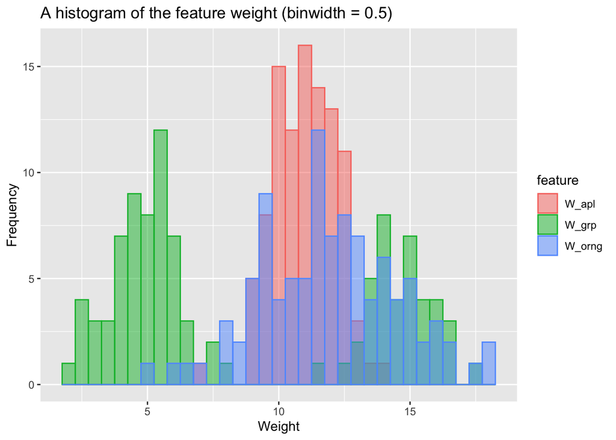

```r
gg$ggplot(data = weight_tidy_data, mapping = gg$aes(fill = feature, color = feature)) +
    gg$geom_histogram(mapping = gg$aes(x = values), alpha = 0.5, position = "identity", binwidth = 0.5)  +
    gg$labs(x = "Weight",
                 y = "Frequency",
                 title = "A histogram of the feature weight (binwidth = 0.5)")
```

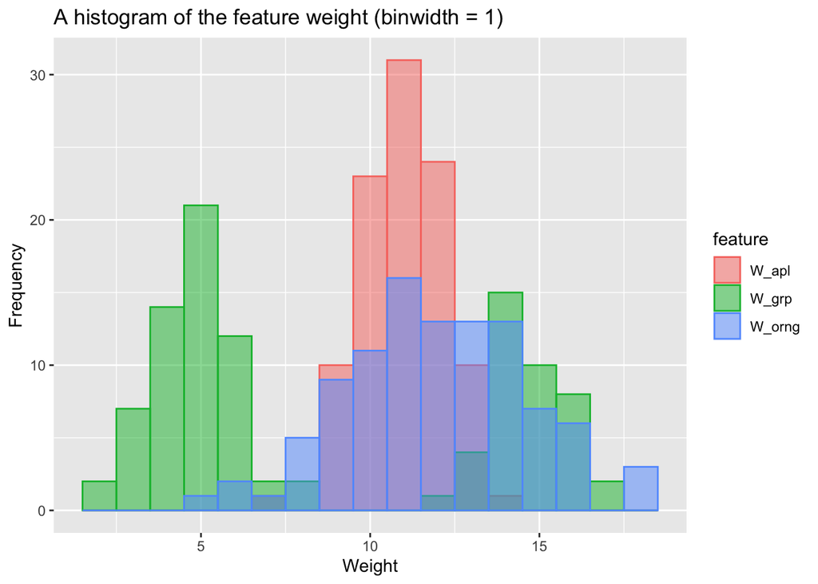

```r
gg$ggplot(data = weight_tidy_data, mapping = gg$aes(fill = feature, color = feature)) +
    gg$geom_histogram(mapping = gg$aes(x = values), alpha = 0.5, position = "identity", binwidth = 1)  +
    gg$labs(x = "Weight",
                 y = "Frequency",
                 title = "A histogram of the feature weight (binwidth = 1)")
```